# Getting Started with GGenemy

## Creating an Accessible Plot

Here’s an improved version:

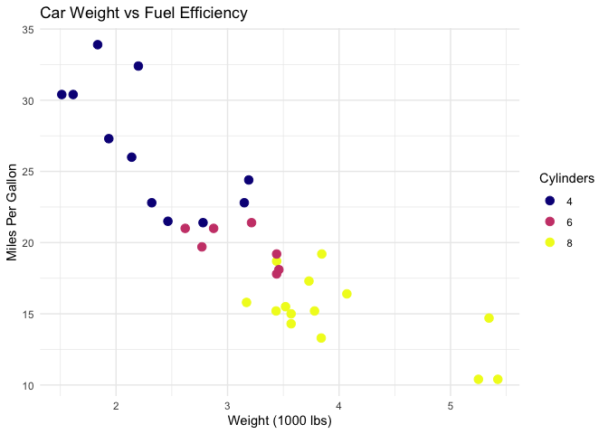

```r
improved_plot <- ggplot(mtcars, aes(wt, mpg, color = factor(cyl))) +
  geom_point(size = 3) +
  scale_color_viridis_d(option = "plasma") +
  labs(
    title = "Car Weight vs Fuel Efficiency",
    x = "Weight (1000 lbs)",
    y = "Miles Per Gallon",
    color = "Cylinders"
  ) +
  theme_minimal()

improved_plot
```

Check it:

```r
gg_audit(improved_plot)
```

```
#>
#> === GGenemy Audit Report ===
#>
#> Plot Type: GeomPoint
#> Layers: 1
#>
#> CRITICAL ISSUES (1):
#>   1. [color] Red-green color combination detected (problematic for 8% of males with deuteranopia/protanopia)
#>
#> WARNINGS (3):
#>   1. [scales] Unusual aspect ratio (6.01) may distort perception of relationships
#>   2. [text] Axis text size (0.8pt) is very small and may be hard to read
#>   3. [text] Title text is smaller than recommended
#>
#> SUGGESTIONS:
#>   - Use colorblind-safe palettes: viridis::scale_color_viridis() or RColorBrewer
#>   - Consider using coord_fixed() for appropriate aspect ratio
#>   - Increase axis text size: theme(axis.text = element_text(size = 10))
#>   - White backgrounds work well, but ensure sufficient contrast with data elements
#>
#> Run gg_suggest_fixes() for code recommendations.
```

```
#> Simulating deutan color vision deficiency...
#> Original colors: #CC4678FF, #0D0887FF, #F0F921FF
#> Simulated colors: #848175FF, #002085FF, #FFF13CFF
```

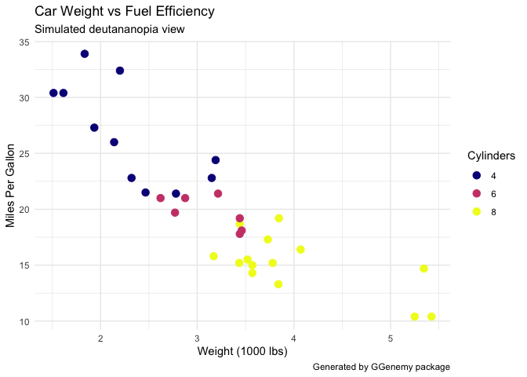

```r
gg_simulate_cvd(improved_plot, type = "deutan")
```

The colors are still distinguishable!

## What GGenemy Checks

### Color Issues

- Red-green combinations
- Too many colors (>7)
- Low contrast colors
- Rainbow palettes (perceptually non-uniform)

### Scale Issues

- Bar charts not starting at zero
- Truncated axes
- Dual y-axes
- Unlabeled log scales
- Inappropriate aspect ratios

### Text Issues

- Text too small
- Overlapping labels
- Missing axis labels
- Long labels that need wrapping

### Accessibility

- Points/lines too small
- Color as the only distinguishing feature
- Missing titles and labels

## Best Practices

1. **Use colorblind-safe palettes**: viridis, plasma, ColorBrewer
2. **Add redundant encoding**: Use both color AND shape
3. **Label everything**: Axes, legends, titles
4. **Start bar charts at zero**
5. **Keep text readable**: Size 10+ points
6. **Test with `gg_simulate_cvd()`**

## Conclusion

GGenemy helps you create visualizations that are accessible, honest, and clear. Run `gg_audit()` on your plots before sharing them!

For more information, visit: https://github.com/andytai7/GGenemy